# Tonnetz vs Chroma vs PCA for Automatic Chord Estimation

**Eight experimental conditions: architecture and parameter count held constant, only input representation varies**

| Model | Input | Dim | Description |
| --- | --- | --- | --- |
| CNN-chroma | librosa CQT chroma | 12 | Standard hand-crafted baseline |
| CNN-deep_chroma | madmom DeepChromaProcessor | 12 | Learned denoised chroma |
| CNN-tonnetz | Tonnetz from CQT chroma | 6 | Theory-driven harmonic projection |
| CNN-tonnetz_deep | Tonnetz from DeepChroma | 6 | Denoised Tonnetz |
| CNN-chroma_pca6 | PCA on CQT chroma | 6 | Data-driven projection (CQT) |
| CNN-deep_chroma_pca6 | PCA on DeepChroma | 6 | Data-driven projection (deep) |
| CNN-chroma_rand6 | Random orthonormal proj. on CQT | 6 | Null baseline (CQT) |
| CNN-deep_chroma_rand6 | Random orthonormal proj. on deep | 6 | Null baseline (deep) |

**Three corpora spanning synth, pop, and classical:**

- **IDMT SMT-Chords** — clean synthesised chords (guitar + non-guitar)
- **Beatles** — Revolver & Sgt Pepper's (real-world pop)
- **Schubert Winterreise** — solo piano, chromatic Romantic harmony (SC06 performance)

**Seven transfer experiments (E1–E7):**

- E1–E2: SMT ↔ Beatles (synth ↔ pop)
- E3–E4: SMT ↔ Schubert (synth ↔ classical)
- E5–E6: SMT ↔ All real (synth ↔ mixed)
- E7: Mixed holdout — cross-genre generalisation

**Evaluation:** Accuracy, Macro/Micro/Weighted F1, TWE (Tonnetz-distance error), MCE (consonance error), error decomposition (root vs quality vs both wrong).

**Result:** The optimal representation depends on harmonic complexity. CNN-deep_chroma_pca6 wins on diatonic pop (Beatles), but CNN-tonnetz_deep dominates on chromatic classical music (Schubert) and cross-genre transfer (6 of 7 experiments overall). The Tonnetz geometry provides a genuine advantage for harmonically complex music.

## 1. Setup

```python
!pip install librosa madmom soundfile --quiet
```

```python
# ── Cell 2: Import everything EXCEPT madmom first ─────────────────────────────
import os, re, warnings
import numpy as np
import pandas as pd
import librosa
import matplotlib.pyplot as plt
import seaborn as sns
from pathlib import Path
from tqdm.notebook import tqdm
import torch
import torch.nn as nn
import torch.nn.functional as F
from torch.utils.data import Dataset, DataLoader, random_split
from sklearn.metrics import f1_score, classification_report, confusion_matrix

warnings.filterwarnings('ignore')
SEED = 42
torch.manual_seed(SEED)
torch.cuda.manual_seed_all(SEED)
np.random.seed(SEED)
DEVICE = torch.device('cuda' if torch.cuda.is_available() else 'cpu')
print(f'Device: {DEVICE}')
torch.backends.cudnn.deterministic = True
torch.backends.cudnn.benchmark = False
```

```
Device: cuda
```

```python
# ── Cell 3: madmom compatibility patches — run AFTER all other imports ─────────
import collections, collections.abc

for _name in ['MutableSequence', 'MutableMapping', 'Callable', 'Mapping',
              'Sequence', 'Iterator', 'Iterable', 'MutableSet']:
    if not hasattr(collections, _name):
        setattr(collections, _name, getattr(collections.abc, _name))

import numpy as _np
for _name, _type in [('float', float), ('int', int), ('complex', complex),
                     ('bool', bool), ('object', object), ('str', str)]:
    if not hasattr(_np, _name):
        setattr(_np, _name, _type)

# ── NOW it's safe to import madmom ────────────────────────────────────────────
import madmom
```

## 2. Configuration

```python
# ── Environment detection ─────────────────────────────────────────────────────
ON_KAGGLE = Path('/kaggle').exists()

if ON_KAGGLE:
    SMT_ROOT     = Path('/kaggle/input/datasets/zburkett44/smt-chords')
    BEATLES_ROOT = Path('/kaggle/input/datasets/zburkett44/chords')
    FEAT_DIR     = Path('/kaggle/working/features')
    OUT_DIR      = Path('/kaggle/working')
    BEATLES_META_PATHS = [
    BEATLES_ROOT / 'revolver_chords'  / 'revolver_chords'    / 'metadata.csv',
    BEATLES_ROOT / 'sgt_peppers_chords' / 'sgt_peppers_chords' / 'metadata.csv',
    ]
    SCHUBERT_ROOT = Path('/kaggle/input/datasets/ollyflaig/schubert-winterreise-chordwise')
else:
    _HERE        = Path.cwd()
    SMT_ROOT     = _HERE / 'IDMT-SMT-CHORDS'
    BEATLES_ROOT = _HERE / 'beatles'
    FEAT_DIR     = _HERE / 'features'
    OUT_DIR      = _HERE / 'features'

    BEATLES_META_PATHS = [
        BEATLES_ROOT / 'revolver_chords'    / 'metadata.csv',
        BEATLES_ROOT / 'sgt_peppers_chords' / 'metadata.csv',
    ]
    SCHUBERT_ROOT = _HERE / 'schubert-winterreise-chordwise'


FEAT_DIR.mkdir(exist_ok=True)
OUT_DIR.mkdir(exist_ok=True)
print(f'Running on Kaggle: {ON_KAGGLE}')
print(f'SMT_ROOT:     {SMT_ROOT}')
print(f'BEATLES_ROOT: {BEATLES_ROOT}')
print(f'FEAT_DIR:     {FEAT_DIR}')
print(f'OUT_DIR:      {OUT_DIR}')

# ── Vocabulary ─────────────────────────────────────────────────────────────────
QUALITIES    = ['maj', 'min']
ROOTS        = ['C','Cs','D','Ds','E','F','Fs','G','Gs','A','As','B']
CHORD_LABELS = [f'{r}:{q}' for r in ROOTS for q in QUALITIES]   # 24 classes
N_CLASSES    = len(CHORD_LABELS)
LABEL2IDX    = {l: i for i, l in enumerate(CHORD_LABELS)}
IDX2LABEL    = {i: l for l, i in LABEL2IDX.items()}

# Root name normalisation: SMT uses C#, Beatles metadata may also vary
ROOT_NORM = {
    'C#':'Cs','D#':'Ds','F#':'Fs','G#':'Gs','A#':'As',
    'Db':'Cs','Eb':'Ds','Gb':'Fs','Ab':'Gs','Bb':'As',
}

# ── Audio / feature settings ───────────────────────────────────────────────────
SR       = 22050
HOP      = 512
N_FRAMES = 32     # fixed time axis — all segments padded/truncated to this

# ── Training hyperparameters ───────────────────────────────────────────────────
BATCH_SIZE = 64
EPOCHS     = 40
LR         = 1e-3
VAL_SPLIT  = 0.2

# ── Colour palette (consistent across all plots) ───────────────────────────────
COLORS = {
    'chroma':       '#4C72B0',
    'deep_chroma':  '#55A868',
    'tonnetz':      '#DD8452',
    'tonnetz_deep': '#C44E52',
}

REP_DIMS = {'chroma':12, 'deep_chroma':12, 'tonnetz':6, 'tonnetz_deep':6}

print(f'Vocabulary: {N_CLASSES} classes')
print(CHORD_LABELS)
```

```
Running on Kaggle: True
SMT_ROOT:     /kaggle/input/datasets/zburkett44/smt-chords
BEATLES_ROOT: /kaggle/input/datasets/zburkett44/chords
FEAT_DIR:     /kaggle/working/features
OUT_DIR:      /kaggle/working
Vocabulary: 24 classes
['C:maj', 'C:min', 'Cs:maj', 'Cs:min', 'D:maj', 'D:min', 'Ds:maj', 'Ds:min', 'E:maj', 'E:min', 'F:maj', 'F:min', 'Fs:maj', 'Fs:min', 'G:maj', 'G:min', 'Gs:maj', 'Gs:min', 'A:maj', 'A:min', 'As:maj', 'As:min', 'B:maj', 'B:min']
```

## 3. Data Loading

### 3a. IDMT SMT-Chords (train/val)

**Layout:** One folder per instrument group (`guitar/`, `non_guitar/`). Each folder contains multiple `.wav` files (one per instrument/sampler) and a single shared `.lab` annotation file. The `.lab` lists `start_time end_time chord_label` at 2-second intervals covering all 7 chord types × 12 roots × inversions × 2 repetitions. We parse the `.lab`, filter to maj/min, strip inversions, and pair each annotation with every wav in the folder.

```python
SMT_ROOT_MAP = {
    'C':'C','C#':'Cs','D':'D','D#':'Ds','E':'E','F':'F',
    'F#':'Fs','G':'G','G#':'Gs','A':'A','A#':'As','B':'B',
    'Db':'Cs','Eb':'Ds','Gb':'Fs','Ab':'Gs','Bb':'As',
}

def parse_lab_file(lab_path: Path) -> list:
    """Parse .lab annotation file → list of {start, end, label} dicts.
    Strips inversion suffix (C:maj/3 → C:maj), filters to maj/min."""
    segments = []
    with open(lab_path) as f:
        for line in f:
            parts = line.strip().split()
            if len(parts) < 3:
                continue
            start, end, chord = float(parts[0]), float(parts[1]), parts[2]
            chord_base = chord.split('/')[0]        # strip inversion
            if ':' not in chord_base:
                continue
            root_raw, quality = chord_base.split(':', 1)
            if quality not in QUALITIES:
                continue
            root = SMT_ROOT_MAP.get(root_raw)
            if root is None:
                continue
            label = f'{root}:{quality}'
            if label not in LABEL2IDX:
                continue
            segments.append({'start': start, 'end': end, 'label': label})
    return segments


def load_smt_metadata(smt_root: Path) -> pd.DataFrame:
    """Walk SMT directory, pair each annotation with every wav in the same folder.
    Returns DataFrame: filepath | start | end | label | family"""
    records = []
    for lab_path in sorted(smt_root.rglob('*.lab')):
        folder  = lab_path.parent
        wavs    = sorted(folder.glob('*.wav'))
        segments = parse_lab_file(lab_path)
        family  = 'guitar' if 'non_guitar' not in str(folder) and 'guitar' in str(folder) else 'non_guitar'
        for wav in wavs:
            for seg in segments:
                records.append({
                    'filepath': str(wav),
                    'start':    seg['start'],
                    'end':      seg['end'],
                    'label':    seg['label'],
                    'family':   family,
                })
    df = pd.DataFrame(records)
    print(f'SMT-Chords: {len(df)} segments across {df["filepath"].nunique()} wavs')
    print(df.groupby('family')['label'].count())
    return df


smt_df = load_smt_metadata(SMT_ROOT)
smt_df.head()
```

```
SMT-Chords: 1908 segments across 16 wavs
family
guitar         468
non_guitar    1440
Name: label, dtype: int64
```

|  | filepath | start | end | label | family |
| --- | --- | --- | --- | --- | --- |
| 0 | /kaggle/input/datasets/zburkett44/smt-chords/I... | 0.0 | 2.0 | E:maj | guitar |
| 1 | /kaggle/input/datasets/zburkett44/smt-chords/I... | 2.0 | 4.0 | F:maj | guitar |
| 2 | /kaggle/input/datasets/zburkett44/smt-chords/I... | 4.0 | 6.0 | Fs:maj | guitar |
| 3 | /kaggle/input/datasets/zburkett44/smt-chords/I... | 6.0 | 8.0 | G:maj | guitar |
| 4 | /kaggle/input/datasets/zburkett44/smt-chords/I... | 8.0 | 10.0 | Gs:maj | guitar |

### 3b. Beatles (test)

Pre-segmented `.wav` files organised by root note. Two albums: Revolver and Sgt. Pepper's. Labels from `metadata.csv`.

```python
def load_beatles_metadata(beatles_root: Path, meta_paths: list) -> pd.DataFrame:
    """Load Beatles segments from metadata CSVs.
    Filters to maj/min, normalises root names, resolves full filepaths."""
    frames = []
    for meta_path in meta_paths:
        if not meta_path.exists():
            print(f'Warning: not found: {meta_path}')
            continue
        meta  = pd.read_csv(meta_path)
        meta  = meta[meta['quality'].isin(QUALITIES)].copy()
        # Normalise root names (C# → Cs, Db → Cs etc.)
        meta['root'] = meta['root'].replace(ROOT_NORM)
        meta  = meta[meta['root'].isin(ROOTS)].copy()
        meta['label'] = meta['root'] + ':' + meta['quality']
        meta  = meta[meta['label'].isin(LABEL2IDX)].copy()
        # Determine album from path
        album = 'revolver' if 'revolver' in str(meta_path).lower() else 'sgt_peppers'
        meta['album'] = album
        # Resolve absolute filepath
        album_dir = meta_path.parent
        def resolve(fp):
            fp_clean = re.sub(r'_(root|inv)', '', str(fp))
            candidate = album_dir / fp_clean
            if candidate.exists():
                return str(candidate)
            matches = list(album_dir.rglob(Path(fp_clean).name))
            return str(matches[0]) if matches else None
        meta['filepath'] = meta['filepath'].apply(resolve)
        meta = meta.dropna(subset=['filepath'])
        frames.append(meta[['filepath','label','root','quality','album']])
    df = pd.concat(frames, ignore_index=True)
    print(f'Beatles: {len(df)} segments (maj/min only)')
    print(df.groupby('album')['label'].count())
    return df


beatles_df = load_beatles_metadata(BEATLES_ROOT, BEATLES_META_PATHS)
beatles_df.head()
```

```
Beatles: 1518 segments (maj/min only)
album
revolver       678
sgt_peppers    840
Name: label, dtype: int64
```

|  | filepath | label | root | quality | album |
| --- | --- | --- | --- | --- | --- |
| 0 | /kaggle/input/datasets/zburkett44/chords/revol... | C:maj | C | maj | revolver |
| 1 | /kaggle/input/datasets/zburkett44/chords/revol... | C:maj | C | maj | revolver |
| 2 | /kaggle/input/datasets/zburkett44/chords/revol... | C:maj | C | maj | revolver |
| 3 | /kaggle/input/datasets/zburkett44/chords/revol... | C:maj | C | maj | revolver |
| 4 | /kaggle/input/datasets/zburkett44/chords/revol... | C:maj | C | maj | revolver |

### 3c. Schubert Winterreise (additional real-world test)

Pre-segmented `.wav` files from the Schubert Winterreise dataset, organised by performance/piece/root/quality. Multiple performances available — we use SC06 as the primary performance and split by piece number for train/test within Schubert.

**Key difference from Beatles:** classical solo piano, chromatic Romantic harmony (chromatic mediants, enharmonic pivots, third-relations) vs. diatonic pop. This tests whether representations that work for pop transfer to a fundamentally different harmonic language.

```python
def load_schubert_metadata(schubert_root: Path) -> pd.DataFrame:
    """Load Schubert Winterreise segments from directory structure.
    Structure: performance/piece/root/quality/*.wav
    Applies root normalisation and filters to 24-class maj/min vocabulary."""
    records = []
    for root_dir, dirs, files in schubert_root.walk(on_error=print):
        for file in files:
            if Path(file).suffix == '.wav':
                metadata = [x.stem for x in (Path(f"{root_dir}/{file}")).parents]
                quality, root_note, piece, performance = metadata[:4]
                # Normalise root names (C# → Cs, Db → Cs, etc.)
                root_note = ROOT_NORM.get(root_note, root_note)
                if root_note not in ROOTS or quality not in QUALITIES:
                    continue
                label = f'{root_note}:{quality}'
                if label not in LABEL2IDX:
                    continue
                records.append({
                    'filepath':    f"{root_dir}/{file}",
                    'piece':       int(piece),
                    'label':       label,
                    'root':        root_note,
                    'quality':     quality,
                    'performance': performance,
                })
    df = pd.DataFrame(records)
    print(f'Schubert Winterreise: {len(df)} segments total')
    print(f'Performances: {sorted(df["performance"].unique())}')
    print(f'Pieces: {df["piece"].nunique()}, Roots: {df["root"].nunique()}')
    print(df.groupby('performance')['label'].count())
    return df


schubert_df_all = load_schubert_metadata(SCHUBERT_ROOT)

# Use SC06 as the primary performance
SCHUBERT_PERF = 'SC06'
schubert_df = schubert_df_all[schubert_df_all['performance'] == SCHUBERT_PERF].copy()
schubert_df = schubert_df.reset_index(drop=True)

# Split by piece number: first half train, second half test
no_pieces = schubert_df['piece'].max()
train_split = 0.5
piece_cutoff = int(train_split * no_pieces)
schubert_train_mask_df = schubert_df['piece'] <= piece_cutoff
schubert_test_mask_df  = schubert_df['piece'] > piece_cutoff

schubert_train_df = schubert_df[schubert_train_mask_df].reset_index(drop=True)
schubert_test_df  = schubert_df[schubert_test_mask_df].reset_index(drop=True)

print(f'\nUsing performance: {SCHUBERT_PERF}')
print(f'Total: {len(schubert_df)}  Train (pieces 1-{piece_cutoff}): {len(schubert_train_df)}  '
      f'Test (pieces {piece_cutoff+1}-{no_pieces}): {len(schubert_test_df)}')
print(f'\nClass distribution (SC06):')
print(schubert_df['label'].value_counts().head(10))
```

```
Schubert Winterreise: 4328 segments total
Performances: ['HU33', 'SC06']
Pieces: 24, Roots: 12
performance
HU33    2164
SC06    2164
Name: label, dtype: int64

Using performance: SC06
Total: 2164  Train (pieces 1-12): 1247  Test (pieces 13-24): 917

Class distribution (SC06):
label
C:maj     174
F:maj     167
D:maj     161
G:maj     159
As:maj    139
C:min     129
A:maj     112
Ds:maj    111
Gs:maj    106
As:min    104
Name: count, dtype: int64
```

### 3d. EDA — class balance

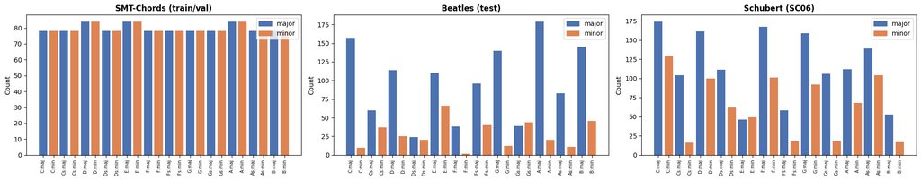

```python
fig, axes = plt.subplots(1, 3, figsize=(20, 4))
from matplotlib.patches import Patch

for ax, df, title in zip(axes,
                         [smt_df,     beatles_df,     schubert_df],
                         ['SMT-Chords (train/val)', 'Beatles (test)', f'Schubert ({SCHUBERT_PERF})']):
    counts = df['label'].value_counts().reindex(CHORD_LABELS, fill_value=0)
    bar_colors = ['#4C72B0' if 'maj' in l else '#DD8452' for l in counts.index]
    ax.bar(range(len(counts)), counts.values, color=bar_colors)
    ax.set_xticks(range(len(counts)))
    ax.set_xticklabels(counts.index, rotation=90, fontsize=7)
    ax.set_title(title, fontweight='bold')
    ax.set_ylabel('Count')
    ax.legend(handles=[Patch(color='#4C72B0',label='major'),
                       Patch(color='#DD8452',label='minor')])

plt.tight_layout()
plt.savefig(str(OUT_DIR / 'class_balance.png'), dpi=150)
plt.show()

# Print Schubert coverage
missing = [l for l in CHORD_LABELS if l not in schubert_df['label'].values]
if missing:
    print(f'Warning: Schubert ({SCHUBERT_PERF}) missing classes: {missing}')
```

## 4. Feature Extraction

Four representations per segment:

| Key | Source | Shape |
| --- | --- | --- |
| `chroma` | librosa CQT chroma | `(N_FRAMES, 12)` |
| `deep_chroma` | madmom DeepChromaProcessor | `(N_FRAMES, 12)` |
| `tonnetz` | Tonnetz from CQT chroma | `(N_FRAMES, 6)` |
| `tonnetz_deep` | Tonnetz from DeepChroma | `(N_FRAMES, 6)` |

Tonnetz dimensions: [P5 sin, P5 cos, m3 sin, m3 cos, M3 sin, M3 cos]

All segments are padded/truncated to `N_FRAMES` then z-score normalised per segment. For SMT, audio is sliced at `.lab` timestamps. For Beatles, pre-cut files are loaded whole. DeepChroma on SMT slices writes a temporary wav (madmom requires a file path).

```python
from madmom.audio.chroma import DeepChromaProcessor
import soundfile as sf, tempfile

DCP = DeepChromaProcessor()

def fix_frames(arr: np.ndarray, n: int) -> np.ndarray:
    """Pad or truncate (T, F) array to (n, F)."""
    T, F = arr.shape
    if T >= n:
        return arr[:n]
    return np.vstack([arr, np.zeros((n-T, F), dtype=arr.dtype)])

def normalise(arr: np.ndarray) -> np.ndarray:
    """Z-score normalise per feature dimension (axis=0 = across time)."""
    mean = arr.mean(axis=0, keepdims=True)   # shape (1, F)
    std  = arr.std(axis=0, keepdims=True)    # shape (1, F)
    return (arr - mean) / (std + 1e-8)

def extract_features(filepath: str, start: float=None, end: float=None) -> dict:
    """Extract all four representations for one audio segment.
    start/end in seconds: used for SMT (long wav). None for Beatles (pre-cut).

    NOTE: fix_frames (pad/truncate) is applied BEFORE normalisation so that
    zero-padding doesn't corrupt the z-score statistics."""
    if start is not None:
        y, sr = librosa.load(filepath, sr=SR, mono=True,
                             offset=start, duration=end-start)
    else:
        y, sr = librosa.load(filepath, sr=SR, mono=True)

    # CQT chroma: (12,T) → (T,12)
    chroma = librosa.feature.chroma_cqt(y=y, sr=sr, hop_length=HOP, fmin=65, n_octaves=5).T

    # Tonnetz from CQT chroma: (6,T) → (T,6)
    tonnetz = librosa.feature.tonnetz(chroma=chroma.T).T

    # DeepChroma: madmom needs a file path, so write tmp wav for SMT slices
    if start is not None:
        with tempfile.NamedTemporaryFile(suffix='.wav', delete=False) as tmp:
            tmp_path = tmp.name
        sf.write(tmp_path, y, SR)
        deep_chroma = DCP(tmp_path).astype(np.float32)   # (T,12)
        os.unlink(tmp_path)
    else:
        deep_chroma = DCP(filepath).astype(np.float32)   # (T,12)

    # Tonnetz from DeepChroma: (6,T) → (T,6)
    tonnetz_deep = librosa.feature.tonnetz(chroma=deep_chroma.T).T

    # fix_frames FIRST (pad/truncate to N_FRAMES), THEN normalise
    return {
        'chroma':       normalise(fix_frames(chroma,       N_FRAMES)),
        'deep_chroma':  normalise(fix_frames(deep_chroma,  N_FRAMES)),
        'tonnetz':      normalise(fix_frames(tonnetz,      N_FRAMES)),
        'tonnetz_deep': normalise(fix_frames(tonnetz_deep, N_FRAMES)),
    }

# Sanity check
_row = smt_df.iloc[0]
_f   = extract_features(_row['filepath'], _row['start'], _row['end'])
for k,v in _f.items():
    print(f'{k:15s}: shape={v.shape}  mean={v.mean():.4f}  std={v.std():.4f}')
```

```
chroma         : shape=(32, 12)  mean=-0.0000  std=0.9574
deep_chroma    : shape=(32, 12)  mean=0.0000  std=1.0000
tonnetz        : shape=(32, 6)  mean=-0.0000  std=1.0000
tonnetz_deep   : shape=(32, 6)  mean=0.0000  std=1.0000
```

```python
def extract_and_cache(df: pd.DataFrame, cache_path: Path) -> dict:
    """Extract features for all rows in df, cache to .npz.
    For SMT rows: uses start/end columns to slice audio.
    For Beatles rows: loads whole pre-cut file."""
    if cache_path.exists():
        print(f'Loading cached features: {cache_path}')
        data = np.load(cache_path)
        return {k: data[k] for k in data.files}

    print(f'Extracting {len(df)} segments...')
    all_feats = {k: [] for k in REP_DIMS}
    labels, failed = [], []
    has_timestamps = 'start' in df.columns

    for _, row in tqdm(df.iterrows(), total=len(df)):
        try:
            start = row['start'] if has_timestamps else None
            end   = row['end']   if has_timestamps else None
            feats = extract_features(row['filepath'], start, end)
            for k in all_feats:
                all_feats[k].append(feats[k])
            labels.append(LABEL2IDX[row['label']])
        except Exception as e:
            failed.append((row['filepath'], str(e)))

    if failed:
        print(f'{len(failed)} files failed:')
        for fp, err in failed[:3]:
            print(f'  {fp}: {err}')

    result = {k: np.stack(v).astype(np.float32) for k, v in all_feats.items()}
    result['labels'] = np.array(labels, dtype=np.int64)
    np.savez(cache_path, **result)
    print(f'Saved to {cache_path}')
    return result


smt_data     = extract_and_cache(smt_df,     FEAT_DIR / 'smt_features.npz')
beatles_data = extract_and_cache(beatles_df, FEAT_DIR / 'beatles_features.npz')

print('\nShapes:')
for k, v in smt_data.items():
    print(f'  SMT     {k:15s}: {v.shape}')
for k, v in beatles_data.items():
    print(f'  Beatles {k:15s}: {v.shape}')
```

```
Loading cached features: /kaggle/working/features/smt_features.npz
Loading cached features: /kaggle/working/features/beatles_features.npz

Shapes:
  SMT     chroma         : (1908, 32, 12)
  SMT     deep_chroma    : (1908, 32, 12)
  SMT     tonnetz        : (1908, 32, 6)
  SMT     tonnetz_deep   : (1908, 32, 6)
  SMT     labels         : (1908,)
  Beatles chroma         : (1518, 32, 12)
  Beatles deep_chroma    : (1518, 32, 12)
  Beatles tonnetz        : (1518, 32, 6)
  Beatles tonnetz_deep   : (1518, 32, 6)
  Beatles labels         : (1518,)
```

```python
# ── Utility for subsetting feature dicts ───────────────────────────────────────
def make_subset(feats, labels, mask):
    """Subset a feature dict by boolean mask."""
    sub = {}
    for k in feats:
        if k == 'labels':
            continue
        sub[k] = feats[k][mask]
    sub['labels'] = labels[mask]
    return sub

def concat_data(*dicts):
    """Concatenate multiple feature dicts."""
    # Get all non-label keys from first dict
    keys = [k for k in dicts[0] if k != 'labels']
    combined = {}
    for k in keys:
        combined[k] = np.concatenate([d[k] for d in dicts], axis=0)
    combined['labels'] = np.concatenate([d['labels'] for d in dicts])
    return combined

# ── Schubert feature extraction ────────────────────────────────────────────────
schubert_data = extract_and_cache(schubert_df, FEAT_DIR / 'schubert_features.npz')

# Feature extraction may drop files (too short for DeepChroma).
# If cached data has fewer rows than schubert_df, filter to loadable files.
n_extracted = len(schubert_data['labels'])
n_original  = len(schubert_df)

if n_extracted < n_original:
    print(f'Note: {n_original - n_extracted} segments failed extraction.')
    print(f'Filtering to loadable files...')
    surviving = []
    for idx in range(n_original):
        row = schubert_df.iloc[idx]
        try:
            y, _ = librosa.load(row['filepath'], sr=SR, mono=True)
            if len(y) > HOP * 2:  # need at least a couple frames
                surviving.append(idx)
        except:
            continue
    surviving = surviving[:n_extracted]
    schubert_df = schubert_df.iloc[surviving].reset_index(drop=True)
    print(f'Aligned: {len(schubert_df)} rows match {n_extracted} extracted segments.')
else:
    schubert_df = schubert_df.reset_index(drop=True)

# Split features by piece mask using the aligned dataframe
schubert_train_mask = np.array([schubert_df.iloc[i]['piece'] <= piece_cutoff
                                for i in range(len(schubert_df))])
schubert_test_mask  = ~schubert_train_mask

schubert_train_data = make_subset(schubert_data, schubert_data['labels'], schubert_train_mask)
schubert_test_data  = make_subset(schubert_data, schubert_data['labels'], schubert_test_mask)

# Pooled real-world data
all_real_data = concat_data(beatles_data, schubert_data)

print(f'\nSchubert features:')
for k, v in schubert_data.items():
    print(f'  {k:15s}: {v.shape}')
print(f'  Train (pieces 1-{piece_cutoff}): {len(schubert_train_data["labels"])}')
print(f'  Test  (pieces {piece_cutoff+1}+):  {len(schubert_test_data["labels"])}')
print(f'\nAll real-world pooled: {len(all_real_data["labels"])} segments')
```

```
Loading cached features: /kaggle/working/features/schubert_features.npz
Note: 9 segments failed extraction.
Filtering to loadable files...
Aligned: 2155 rows match 2155 extracted segments.

Schubert features:
  chroma         : (2155, 32, 12)
  deep_chroma    : (2155, 32, 12)
  tonnetz        : (2155, 32, 6)
  tonnetz_deep   : (2155, 32, 6)
  labels         : (2155,)
  Train (pieces 1-12): 1243
  Test  (pieces 13+):  912

All real-world pooled: 3673 segments
```

## 4b. PCA Ablation — Per-Experiment Projection Fitting

The PCA ablation compares three 6-D projection methods against the 4 base representations:

| Projection | Description | Data-dependent? |
| --- | --- | --- |
| **Tonnetz** | Fixed Harte (2006) geometry: circle of fifths + thirds | No — same transform everywhere |
| **PCA-6** | Top 6 principal components of the 12-D chroma | **Yes — fitted on training data of each experiment** |
| **Random-6** | Random orthonormal basis | No — fixed random matrix |

PCA is fitted on the *training data* of each experiment separately, then applied to both train and test. This ensures a fair comparison, Tonnetz uses no training data, so PCA shouldn't get an unfair advantage from seeing data outside the current experiment's training set.

The random projection uses a fixed orthonormal matrix (same across all experiments) as a null baseline: if random projections work as well as PCA, the specific PCA directions don't matter.

### PCA Explained Variance

PCA variance is computed per-experiment within `run_experiment` below.

## 5. Dataset & DataLoaders

```python
class ChordDataset(Dataset):
    """Wraps (N,T,F) feature array + (N,) label array.
    Adds channel dim: (N,T,F) → (N,1,T,F) for Conv2d."""
    def __init__(self, features: np.ndarray, labels: np.ndarray):
        self.X = torch.tensor(features[:, None, :, :], dtype=torch.float32)
        self.y = torch.tensor(labels, dtype=torch.long)
    def __len__(self):   return len(self.y)
    def __getitem__(self, i): return self.X[i], self.y[i]


def seed_worker(worker_id):
    np.random.seed(SEED + worker_id)
    import random; random.seed(SEED + worker_id)

g = torch.Generator()
g.manual_seed(SEED)

def make_loaders(data: dict, rep: str, val_split: float = VAL_SPLIT,
                 val_data: dict = None):
    """If val_data is provided, use it as the fixed validation set (no random split)."""
    if val_data is not None:
        train_ds = ChordDataset(data[rep], data['labels'])
        val_ds   = ChordDataset(val_data[rep], val_data['labels'])
    else:
        ds = ChordDataset(data[rep], data['labels'])
        n_val   = int(len(ds) * val_split)
        n_train = len(ds) - n_val
        train_ds, val_ds = random_split(ds, [n_train, n_val],
                                        generator=torch.Generator().manual_seed(SEED))

    g = torch.Generator()          # fresh generator every call
    g.manual_seed(SEED)

    train_loader = DataLoader(train_ds, batch_size=BATCH_SIZE, shuffle=True,
                              num_workers=0, worker_init_fn=seed_worker, generator=g)
    val_loader   = DataLoader(val_ds, batch_size=BATCH_SIZE, shuffle=False,
                              num_workers=0, worker_init_fn=seed_worker)
    return train_loader, val_loader

def make_test_loader(data: dict, rep: str):
    ds = ChordDataset(data[rep], data['labels'])
    return DataLoader(ds, batch_size=BATCH_SIZE, shuffle=False,
                      num_workers=0)
```

## 6. CNN Architecture

Same architecture across all conditions, only input feature dimension differs (12 for chroma variants, 6 for Tonnetz/PCA/random variants). This isolates the effect of the representation.

**Parameter count is identical (134,136) across all conditions.**

```python
class ChordCNN(nn.Module):
    """Input: (B, 1, N_FRAMES, n_features)  Output: (B, N_CLASSES) logits"""
    def __init__(self, n_features: int, n_classes: int=N_CLASSES):
        super().__init__()
        self.conv1 = nn.Sequential(
            nn.Conv2d(1,  32, kernel_size=(8,3), padding=(4,1)),
            nn.BatchNorm2d(32), nn.ReLU())
        self.conv2 = nn.Sequential(
            nn.Conv2d(32, 64, kernel_size=(4,3), padding=(2,1)),
            nn.BatchNorm2d(64), nn.ReLU(),
            nn.MaxPool2d(kernel_size=(2,1)))   # pool time only
        self.conv3 = nn.Sequential(
            nn.Conv2d(64, 128, kernel_size=(4,3), padding=(2,1)),
            nn.BatchNorm2d(128), nn.ReLU(),
            nn.MaxPool2d(kernel_size=(2,1)))   # pool time only
        self.gap = nn.AdaptiveAvgPool2d((1,1))
        self.head = nn.Sequential(
            nn.Dropout(0.5),
            nn.Linear(128, 64), nn.ReLU(),
            nn.Linear(64, n_classes))

    def forward(self, x):
        x = self.conv3(self.conv2(self.conv1(x)))
        return self.head(self.gap(x).flatten(1))

    def get_first_layer_filters(self):
        """Returns (n_filters, kH, kW) numpy array."""
        return self.conv1[0].weight.detach().cpu().numpy()[:, 0, :, :]

# Shape verification
for name, n in [('chroma',12),('tonnetz',6)]:
    m   = ChordCNN(n_features=n)
    out = m(torch.zeros(4,1,N_FRAMES,n))
    params = sum(p.numel() for p in m.parameters())
    print(f'{name:12s}  input=(4,1,{N_FRAMES},{n})  output={tuple(out.shape)}  params={params:,}')
```

```
chroma        input=(4,1,32,12)  output=(4, 24)  params=134,136
tonnetz       input=(4,1,32,6)  output=(4, 24)  params=134,136
```

## 7. Training & Evaluation Utilities

```python
def train_model(rep: str, n_features: int, train_loader, val_loader,
                epochs: int=EPOCHS) -> tuple:
    """Train ChordCNN, return (best_model, history_dict)."""
    model     = ChordCNN(n_features=n_features).to(DEVICE)
    optimiser = torch.optim.Adam(model.parameters(), lr=LR, weight_decay=1e-4)
    scheduler = torch.optim.lr_scheduler.CosineAnnealingLR(optimiser, T_max=epochs)
    criterion = nn.CrossEntropyLoss()
    history   = {'train_loss':[], 'val_loss':[], 'val_acc':[]}
    best_acc, best_state = 0.0, None

    for epoch in range(1, epochs+1):
        model.train()
        train_loss = 0.0
        for X, y in train_loader:
            X, y = X.to(DEVICE), y.to(DEVICE)
            optimiser.zero_grad()
            loss = criterion(model(X), y)
            loss.backward(); optimiser.step()
            train_loss += loss.item() * len(y)
        train_loss /= len(train_loader.dataset)

        model.eval(); val_loss = correct = 0
        with torch.no_grad():
            for X, y in val_loader:
                X, y = X.to(DEVICE), y.to(DEVICE)
                logits = model(X)
                val_loss += criterion(logits, y).item() * len(y)
                correct  += (logits.argmax(1)==y).sum().item()
        val_loss /= len(val_loader.dataset)
        val_acc   = correct / len(val_loader.dataset)
        history['train_loss'].append(train_loss)
        history['val_loss'].append(val_loss)
        history['val_acc'].append(val_acc)
        scheduler.step()
        if val_acc > best_acc:
            best_acc   = val_acc
            best_state = {k: v.clone() for k,v in model.state_dict().items()}
        if epoch % 10 == 0:
            print(f'  epoch {epoch:3d}/{epochs}  '
                  f'train={train_loss:.4f}  val={val_loss:.4f}  acc={val_acc:.4f}')

    model.load_state_dict(best_state)
    return model, history


def evaluate(model: nn.Module, loader: DataLoader) -> tuple:
    """Return (preds, targets) as numpy arrays."""
    model.eval(); preds, targets = [], []
    with torch.no_grad():
        for X, y in loader:
            preds.extend(model(X.to(DEVICE)).argmax(1).cpu().numpy())
            targets.extend(y.numpy())
    return np.array(preds), np.array(targets)


# ── Evaluation metrics ────────────────────────────────────────────────────────

# Tonnetz distance matrix over 12 roots
def _build_tonnetz_dist():
    """Tonal centroid vectors per Harte et al. (2006) eq. 3.
    Radii: r1=r2=1 (fifths, minor thirds), r3=0.5 (major thirds)."""
    r = [1.0, 1.0, 0.5]
    def vec(l):
        return np.array([
            r[0] * np.sin(l * 7*np.pi/6),   r[0] * np.cos(l * 7*np.pi/6),   # P5
            r[1] * np.sin(l * 3*np.pi/2),   r[1] * np.cos(l * 3*np.pi/2),   # m3
            r[2] * np.sin(l * 2*np.pi/3),   r[2] * np.cos(l * 2*np.pi/3),   # M3
        ])
    vecs = np.stack([vec(i) for i in range(12)])
    D = np.zeros((12, 12))
    for i in range(12):
        for j in range(12):
            D[i, j] = np.linalg.norm(vecs[i] - vecs[j])
    return D

ROOT_DIST = _build_tonnetz_dist()

# Consonance vector
# Index = semitones, value = dissonance score (lower = more consonant)
# [P1, m2, M2, m3, M3, P4, TT, P5, m6, M6, m7, M7]
CONSONANCE_VEC = np.array([0,7,5,1,1,2,3,1,2,2,4,6], dtype=float)

def compute_metrics(preds, targets) -> dict:
    """Compute all evaluation metrics for a set of predictions."""
    acc       = (preds==targets).mean()
    macro_f1  = f1_score(targets, preds, average='macro',    zero_division=0)
    weighted_f1 = f1_score(targets, preds, average='weighted', zero_division=0)

    # Maj/min split
    maj_mask = np.array([IDX2LABEL[t].endswith('maj') for t in targets])
    min_mask = ~maj_mask
    _maj_labels = [i for i, l in IDX2LABEL.items() if l.endswith('maj')]
    _min_labels = [i for i, l in IDX2LABEL.items() if l.endswith('min')]
    maj_f1 = f1_score(targets[maj_mask], preds[maj_mask],
                      labels=[l for l in _maj_labels if l in set(targets[maj_mask])],
                      average='macro', zero_division=0)
    min_f1 = f1_score(targets[min_mask], preds[min_mask],
                      labels=[l for l in _min_labels if l in set(targets[min_mask])],
                      average='macro', zero_division=0)

    # TWE — Tonnetz-distance weighted error
    def twe_dist(p, t):
        ra, qa = IDX2LABEL[p].split(':'); rb, qb = IDX2LABEL[t].split(':')
        return ROOT_DIST[ROOTS.index(ra), ROOTS.index(rb)] + (0.0 if qa==qb else 0.5)
    twe = np.mean([twe_dist(int(p),int(t)) for p,t in zip(preds,targets)])

    # MCE — Mechanical-Consonance error
    def mce_dist(p, t):
        ra, qa = IDX2LABEL[p].split(':'); rb, qb = IDX2LABEL[t].split(':')
        ia, ib = ROOTS.index(ra), ROOTS.index(rb)
        interval = (ib - ia) % 12
        return float(CONSONANCE_VEC[interval]) + (0.0 if qa==qb else 1.0)
    mce = np.mean([mce_dist(int(p),int(t)) for p,t in zip(preds,targets)])

    return dict(acc=acc, macro_f1=macro_f1, weighted_f1=weighted_f1,
                maj_f1=maj_f1, min_f1=min_f1, twe=twe, mce=mce)

from sklearn.decomposition import PCA

# Fixed random orthonormal projections (same across all experiments — null baseline)
_rng = np.random.default_rng(SEED)
Q_CHROMA, _ = np.linalg.qr(_rng.standard_normal((12, 6)))
Q_DEEP,   _ = np.linalg.qr(_rng.standard_normal((12, 6)))

# Extended representation config (base 4 + PCA + random = 8 total)
ALL_REP_DIMS = {
    'chroma': 12, 'deep_chroma': 12, 'tonnetz': 6, 'tonnetz_deep': 6,
    'chroma_pca6': 6, 'deep_chroma_pca6': 6,
    'chroma_rand6': 6, 'deep_chroma_rand6': 6,
}
ALL_COLORS = {
    **COLORS,
    'chroma_pca6': '#9B59B6', 'deep_chroma_pca6': '#1ABC9C',
    'chroma_rand6': '#BDC3C7', 'deep_chroma_rand6': '#7F8C8D',
}

def add_projections(data, pca_chroma, pca_deep):
    """Add PCA and random projections to a feature dict in-place."""
    for src, dst, proj in [
        ('chroma',      'chroma_pca6',      lambda x: pca_chroma.transform(x)),
        ('deep_chroma', 'deep_chroma_pca6', lambda x: pca_deep.transform(x)),
        ('chroma',      'chroma_rand6',     lambda x: x @ Q_CHROMA),
        ('deep_chroma', 'deep_chroma_rand6',lambda x: x @ Q_DEEP),
    ]:
        N, T, F = data[src].shape
        data[dst] = proj(data[src].reshape(-1, F)).reshape(N, T, 6).astype(np.float32)


def run_experiment(train_feats, test_feats, exp_name, epochs=EPOCHS,
                   val_feats=None, verbose_pca=False):
    """Train all 8 representation variants, evaluate on test_feats.

    PCA is fitted on the TRAINING data of this experiment only,
    then applied to train, val, and test. This ensures a fair comparison
    with Tonnetz (which uses no training data).
    """
    # ── Step 1: Fit PCA on training data ──────────────────────────────────────
    pca_chroma = PCA(n_components=6, random_state=SEED).fit(
        train_feats['chroma'].reshape(-1, 12))
    pca_deep = PCA(n_components=6, random_state=SEED).fit(
        train_feats['deep_chroma'].reshape(-1, 12))

    if verbose_pca:
        print(f'  [{exp_name}] PCA explained variance:')
        print(f'    chroma:      {pca_chroma.explained_variance_ratio_.cumsum()[-1]:.3f}')
        print(f'    deep_chroma: {pca_deep.explained_variance_ratio_.cumsum()[-1]:.3f}')

    # ── Step 2: Apply projections to all data splits ──────────────────────────
    # Work on copies so we don't mutate the originals
    train_ext = {k: v.copy() if isinstance(v, np.ndarray) else v
                 for k, v in train_feats.items()}
    test_ext  = {k: v.copy() if isinstance(v, np.ndarray) else v
                 for k, v in test_feats.items()}
    add_projections(train_ext, pca_chroma, pca_deep)
    add_projections(test_ext,  pca_chroma, pca_deep)

    val_ext = None
    if val_feats is not None:
        val_ext = {k: v.copy() if isinstance(v, np.ndarray) else v
                   for k, v in val_feats.items()}
        add_projections(val_ext, pca_chroma, pca_deep)

    # ── Step 3: Train and evaluate all 8 representations ──────────────────────
    exp_res, exp_hist = {}, {}
    for rep, n_feat in ALL_REP_DIMS.items():
        print(f'  [{exp_name}] CNN-{rep}...')
        tl, vl = make_loaders(train_ext, rep, val_data=val_ext)
        model, hist = train_model(rep, n_feat, tl, vl, epochs=epochs)
        preds, targets = evaluate(model, make_test_loader(test_ext, rep))
        metrics = compute_metrics(preds, targets)
        exp_res[rep]  = {'preds': preds, 'targets': targets, **metrics}
        exp_hist[rep] = hist
        print(f'    acc={metrics["acc"]:.4f}  macro_f1={metrics["macro_f1"]:.4f}  '
              f'maj_f1={metrics["maj_f1"]:.4f}  min_f1={metrics["min_f1"]:.4f}')

    return exp_res, exp_hist


def summarise(exp_res, exp_name):
    rows = [{'Model': f'CNN-{r}', 'Accuracy': round(v['acc'], 4),
             'Macro F1': round(v['macro_f1'], 4), 'Maj F1': round(v['maj_f1'], 4),
             'Min F1': round(v['min_f1'], 4), 'TWE': round(v['twe'], 4),
             'MCE': round(v['mce'], 4)}
            for r, v in exp_res.items()]
    df = pd.DataFrame(rows).sort_values('Macro F1', ascending=False)
    print(f'\n{exp_name}')
    print(df.to_string(index=False))
    safe_name = exp_name.replace(' ', '_').replace('\u2192', 'to').replace('→', 'to')
    df.to_csv(str(OUT_DIR / f'{safe_name}.csv'), index=False)
    return df

def split_feats(feats, val_split=VAL_SPLIT, seed=SEED):
    """Split a feature dict into (train_feats, val_feats) by random index."""
    n = len(feats['labels'])
    rng = np.random.default_rng(seed)
    idx = rng.permutation(n)
    n_val = int(n * val_split)
    val_idx, train_idx = idx[:n_val], idx[n_val:]
    def subset(f, i):
        sub = {}
        for k in f:
            sub[k] = f[k][i]
        return sub
    return subset(feats, train_idx), subset(feats, val_idx)
```

## 8. Main Experiment: SMT → Beatles

```python
# ── E1: SMT → Beatles (main experiment) ───────────────────────────────────────
print('E1: Train=SMT  Test=Beatles')
results, histories = run_experiment(smt_data, beatles_data, 'E1_SMT_to_Beatles',
                                    verbose_pca=True)
df_e1 = summarise(results, 'E1 SMT→Beatles')

# Store trained models for filter visualisation later
# (Re-train just the 3 we need for filter vis)
trained_models = {}
for rep in ['tonnetz', 'tonnetz_deep', 'deep_chroma_pca6']:
    print(f'  Re-training CNN-{rep} for filter visualisation...')
    # Need to build extended data with PCA for this
    pca_c = PCA(n_components=6, random_state=SEED).fit(smt_data['chroma'].reshape(-1, 12))
    pca_d = PCA(n_components=6, random_state=SEED).fit(smt_data['deep_chroma'].reshape(-1, 12))
    smt_ext = {k: v.copy() for k, v in smt_data.items()}
    add_projections(smt_ext, pca_c, pca_d)
    tl, vl = make_loaders(smt_ext, rep)
    model, _ = train_model(rep, ALL_REP_DIMS[rep], tl, vl)
    trained_models[rep] = model
```

```
E1: Train=SMT  Test=Beatles
  [E1_SMT_to_Beatles] PCA explained variance:
    chroma:      0.795
    deep_chroma: 0.955
  [E1_SMT_to_Beatles] CNN-chroma...
  epoch  10/40  train=1.9600  val=1.9360  acc=0.4121
  epoch  20/40  train=1.2408  val=1.6029  acc=0.5302
  epoch  30/40  train=0.9611  val=1.1806  acc=0.6273
  epoch  40/40  train=0.8815  val=1.0793  acc=0.6824
    acc=0.1449  macro_f1=0.1098  maj_f1=0.1376  min_f1=0.1864
  [E1_SMT_to_Beatles] CNN-deep_chroma...
  epoch  10/40  train=1.0585  val=2.1117  acc=0.3491
  epoch  20/40  train=0.5511  val=0.8043  acc=0.8425
  epoch  30/40  train=0.3846  val=0.5391  acc=0.8819
  epoch  40/40  train=0.3314  val=0.4963  acc=0.9029
    acc=0.2912  macro_f1=0.2555  maj_f1=0.3328  min_f1=0.2498
  [E1_SMT_to_Beatles] CNN-tonnetz...
  epoch  10/40  train=0.7484  val=1.9098  acc=0.4278
  epoch  20/40  train=0.3588  val=1.4390  acc=0.6483
  epoch  30/40  train=0.2244  val=0.6672  acc=0.8241
  epoch  40/40  train=0.1999  val=0.5882  acc=0.8189
    acc=0.2576  macro_f1=0.2209  maj_f1=0.3087  min_f1=0.3399
  [E1_SMT_to_Beatles] CNN-tonnetz_deep...
  epoch  10/40  train=0.3776  val=0.5332  acc=0.8976
  epoch  20/40  train=0.2088  val=0.5250  acc=0.8950
  epoch  30/40  train=0.1231  val=0.5237  acc=0.9029
  epoch  40/40  train=0.1053  val=0.5242  acc=0.9055
    acc=0.4124  macro_f1=0.3537  maj_f1=0.4683  min_f1=0.4292
  [E1_SMT_to_Beatles] CNN-chroma_pca6...
  epoch  10/40  train=0.8261  val=1.1942  acc=0.6247
  epoch  20/40  train=0.4129  val=1.2296  acc=0.7060
  epoch  30/40  train=0.2638  val=0.5770  acc=0.8373
  epoch  40/40  train=0.2297  val=0.5348  acc=0.8583
    acc=0.2016  macro_f1=0.1714  maj_f1=0.2633  min_f1=0.1925
  [E1_SMT_to_Beatles] CNN-deep_chroma_pca6...
  epoch  10/40  train=0.5273  val=0.7371  acc=0.8215
  epoch  20/40  train=0.2410  val=0.5306  acc=0.8845
  epoch  30/40  train=0.1644  val=0.4518  acc=0.9081
  epoch  40/40  train=0.1149  val=0.4355  acc=0.9055
    acc=0.4433  macro_f1=0.3897  maj_f1=0.4952  min_f1=0.5094
```

[output cut: 23 more lines]

```
  Re-training CNN-tonnetz for filter visualisation...
  epoch  10/40  train=0.7586  val=1.4823  acc=0.5722
  epoch  20/40  train=0.3791  val=0.9566  acc=0.7664
  epoch  30/40  train=0.2125  val=0.5490  acc=0.8268
  epoch  40/40  train=0.1988  val=0.5428  acc=0.8399
  Re-training CNN-tonnetz_deep for filter visualisation...
  epoch  10/40  train=0.3666  val=0.4886  acc=0.8950
  epoch  20/40  train=0.2088  val=0.4423  acc=0.9055
  epoch  30/40  train=0.1167  val=0.4612  acc=0.9055
  epoch  40/40  train=0.0804  val=0.4577  acc=0.9081
  Re-training CNN-deep_chroma_pca6 for filter visualisation...
  epoch  10/40  train=0.5740  val=0.9099  acc=0.7349
  epoch  20/40  train=0.2974  val=0.5540  acc=0.8583
  epoch  30/40  train=0.1691  val=0.5773  acc=0.8766
  epoch  40/40  train=0.1383  val=0.4888  acc=0.8950
```

### 8a. Training curves

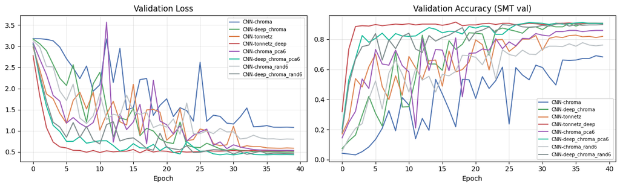

```python
fig, axes = plt.subplots(1,2, figsize=(13,4))
for rep, hist in histories.items():
    axes[0].plot(hist['val_loss'], label=f'CNN-{rep}', color=ALL_COLORS.get(rep, '#333'))
    axes[1].plot(hist['val_acc'],  label=f'CNN-{rep}', color=ALL_COLORS.get(rep, '#333'))
axes[0].set_title('Validation Loss'); axes[0].set_xlabel('Epoch')
axes[1].set_title('Validation Accuracy (SMT val)'); axes[1].set_xlabel('Epoch')
for ax in axes:
    ax.legend(fontsize=7); ax.grid(alpha=0.3)
plt.tight_layout()
plt.savefig(str(OUT_DIR / 'training_curves.png'), dpi=150); plt.show()
```